# sales

Bonus Project

Tesanca Anggara 洪鳳璘

1. Load the Dataset

command :

Import pandas as pd for load the data, import matplotlib.pyplot as plt to create plot

output :

Pandas and matplotlib.pyplot are imported

```python
import pandas as pd
import matplotlib.pyplot as plt
```

command :

Read the monthly_sales data to pd and we named it df

output :

df has already become the imported data as pd

```python
df = pd.read_csv("/Users/hermawansutrisno/Documents/tesanca's/S2/SEMESTER 1/data science/monthly_sales.csv")
```

command :

To check (rows, columns)

output :

It means there are 12 rows and 2 columns

```python
df.shape
```

```
(12, 2)
```

command :

To know every information about the data (column, rows, column names, data type)

output :

There are 12 rows, 2 columns, column names (Month and Sales), data type: int64(1), object(1)

```python
df.info()
```

```
<class 'pandas.core.frame.DataFrame'>
RangeIndex: 12 entries, 0 to 11
Data columns (total 2 columns):
 #   Column  Non-Null Count  Dtype
---  ------  --------------  -----
 0   Month   12 non-null     object
 1   Sales   12 non-null     int64
dtypes: int64(1), object(1)
memory usage: 324.0+ bytes
```

command :

To know the first few rows of data

output :

It shows the first 5 rows and 2 columns of the data

```python
df.head()
```

|  | Month | Sales |
| --- | --- | --- |
| 0 | January | 1000 |
| 1 | February | 1500 |
| 2 | March | 1200 |
| 3 | April | 1700 |
| 4 | May | 1600 |

command :

To know the last few rows of data

output :

It shows the last 5 rows and 2 columns of the data

```python
df.tail()
```

|  | Month | Sales |
| --- | --- | --- |
| 7 | August | 1900 |
| 8 | September | 2200 |
| 9 | October | 2100 |
| 10 | November | 2300 |
| 11 | December | 2500 |

2. Data Cleaning

command :

To check wether there is missing value or no

output :

There is no missing values on month and sales

```python
df.isnull().sum()
```

```
Month    0
Sales    0
dtype: int64
```

3. Exploratory Data Analysis (EDA)

command :

df.describe(), to describe count(number of no missing values in Sales), mean (total average in Sales), min (lowest values in Sales), max (highest values in sales)

output :

count (there are 12 values), mean (the average is 1816.6), min (lowest value is 1000), max(highest value is 2500)

```python
print(df.describe())
```

```
             Sales
count    12.000000
mean   1816.666667
std     444.835686
min    1000.000000
25%    1575.000000
50%    1850.000000
75%    2125.000000
max    2500.000000
```

command :

We want to clarify the lowest_sales(min), highest_sales(max), average_sales(mean), total_sales(sum) from our data (df['Sales'])

output :

So now we can see all the highest, lowest, average, and total sales clearly

```python
lowest_sales = df['Sales'].min()
highest_sales = df['Sales'].max()
average_sales = df['Sales'].mean()
total_sales = df['Sales'].sum()

print(f"Lowest_sales  : {lowest_sales}")
print(f"Highest_sales : {highest_sales}")
print(f"Average_sales : {average_sales}")
print(f"Total_sales   : {total_sales}")
```

```
Lowest_sales  : 1000
Highest_sales : 2500
Average_sales : 1816.6666666666667
Total_sales   : 21800
```

command :

we want to identify the highest sales from the data (df). we name it with highest_sales_month

output :

know we now that the highest sales is in December

```python
highest_sales_month = df[df['Sales'] == highest_sales]['Month'].values[0]
print(f"Highest_sales_month : {highest_sales} in {highest_sales_month} ")
```

```
Highest_sales_month : 2500 in December
```

command :

we want to identify the lowest sales from the data (df). we name it with lowest_sales_month

output :

know we now that the lowest sales is in January

```python
lowest_sales_month = df[df['Sales'] == lowest_sales]['Month'].values[0]
print(f"Lowest_sales_month : {lowest_sales} in {lowest_sales_month} ")
```

```
Lowest_sales_month : 1000 in January
```

4. Data Visualization

command :

listx (will appear Month data(df) for x-axis)

listy(will appear Sales data(df) for y-axis)

figsize(to specidy the wide and tall in inches)

plt.plot (is command to make the graphs and we colour it with green also with the point marker every month with dot)

plt.grid(to make grid in the background so we can see the graph more clearly)

plt.title(we want to name the graph 'Monthly Sales')

plt.xticks(we want each month to fit in the graph, so we want to rotate the word a little bit. so all months will fit.)

output :

We can see that overall sales is increasing. But there are 4 times the sales were decreasing on March, May, August, and October. And from the grpahs we can see that we reach the highest sales on December which is 2500 and the lowest is on January for 1000

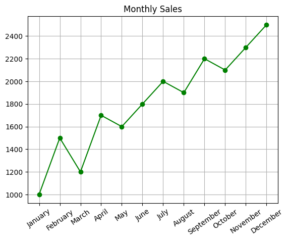

```python
listx = df['Month']
listy = df['Sales']
figsize = (15,10)
plt.plot(listx, listy,color = 'green', marker = 'o')
plt.grid()
plt.title('Monthly Sales')
plt.xticks(rotation= 35)
plt.show()
```